# Simulated Datasets With Binary Outcomes

## Calculate Variable Importance

Variable importance can be calculated in a multitude of different ways. Here I am using a method called Nearest-neighbor Projected Distance Regression (NPDR), which allows for hypothesis testing and a measure of statistical significance (i.e., p-values), covariate adjustment (e.g., age, sex, ancestry, etc), in addition to feature selection using a LASSO penalty.<sup>3</sup>

The output from `npdr()` is a dataframe with multiple columns. The variable importance (`beta.Z.att`) is a standardized effect size, and the corresponding p-value (`pval.att`) is calculated from a one-sided hypothesis test; the bonferroni-adusted p-value (`pval.adj`) is also present. As shown in the table below, the features with the largest importance scores are those that were simulated to have a main effect or interaction effect, respectively.

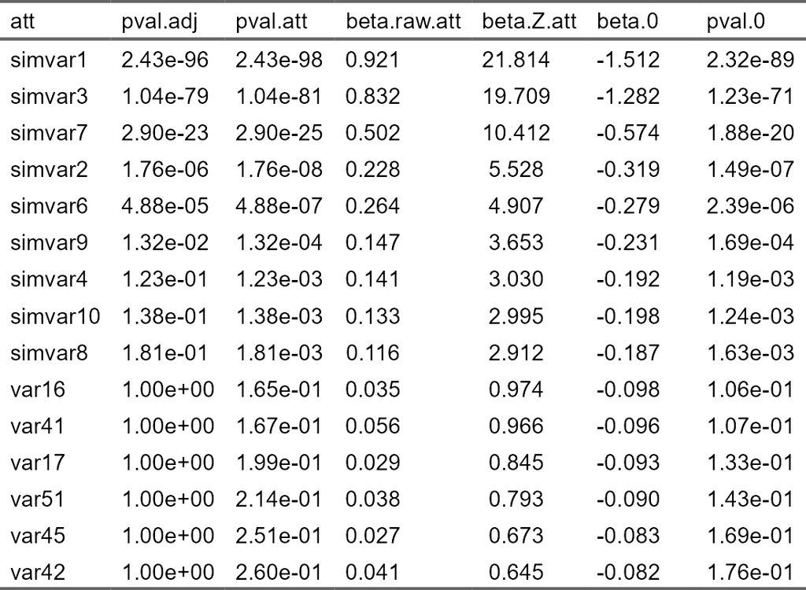

```r
npdr_res <- npdr(outcome = "class",
                 dataset = sim.dats,
                 regression.type = "binomial",
                 attr.diff.type = "numeric-abs",
                 nbd.method = "relieff",
                 nbd.metric = "manhattan",
                 knn = 0)

head(npdr_res, n = 15) |>
  mutate(across(c(2,3, ncol(npdr_res)), ~format(.x, digits = 3))) |>
  mutate(across(where(is.numeric), ~format(round(.x, digits = 3), nsmall = 3))) |>
  flextable() |>
  set_table_properties(align = "center")
```

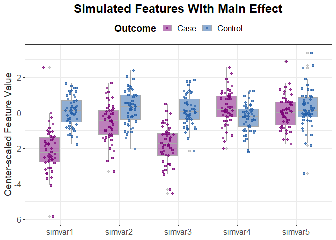

```r
# Main Effect Features
plot_df <- sim.dats |>
  select(all_of(c(paste0("simvar", 1:5), "class"))) |>
  mutate(Outcome = factor(case_when(
    class == 1 ~ "Case",
    TRUE ~ "Control"
  ), levels = c("Case", "Control"))) |>
  pivot_longer(cols = paste0("simvar", 1:5), values_to = "Center-scaled Feature Value", names_to = "Feature") |>
  mutate(Feature = as.factor(Feature))

ggplot(plot_df, aes(x = Feature, y = `Center-scaled Feature Value`, color = Outcome, fill = Outcome, alpha = Outcome)) +
  geom_boxplot(color = "darkgray", alpha = 0.5) +
  geom_point(position = position_jitterdodge(seed = 1234), alpha = 0.7) +
  scale_color_manual(breaks = c("Case", "Control"), values = c("#7a0177", "#225ea8")) +
  scale_fill_manual(breaks = c("Case", "Control"), values = c("#7a0177", "#225ea8")) +
  theme_bw() +
  ggtitle("Simulated Features With Main Effect") +
  theme(axis.title.x = element_blank(),
        legend.position = "top",
        legend.text = element_text(size = 12),
        legend.title = element_text(size = 14, face = "bold"),
        axis.text = element_text(size = 12),
        axis.title.y = element_text(size = 14, color = "#252525"),
        plot.title = element_text(size = 18, face = "bold", color = "black", hjust = 0.5))
```

## References

1. Leek, J. T., and J. D. Storey. “Capturing Heterogeneity in Gene Expression Studies by Surrogate Variable Analysis.” PLoS Genet 3, no. 9 (Sep 2007): 1724-35. https://dx.doi.org/10.1371/journal.pgen.0030161.
2. Lareau, C. A., B. C. White, A. L. Oberg, and B. A. McKinney. “Differential Co-Expression Network Centrality and Machine Learning Feature Selection for Identifying Susceptibility Hubs in Networks with Scale-Free Structure.” BioData Min 8 (2015): 5. https://dx.doi.org/10.1186/s13040-015-0040-x.
3. Le, Trang T, Bryan A Dawkins, and Brett A McKinney. “Nearest-Neighbor Projected-Distance Regression (NPDR) for Detecting Network Interactions with Adjustments for Multiple Tests and Confounding.” Bioinformatics 36, no. 9 (2020): 2770-77. Accessed 5/6/2022. https://dx.doi.org/10.1093/bioinformatics/btaa024.